# Google Play Store App Analysis

## by Harutaka Kawamura

## Dataset Overview

> This dataset contains all the details of the applications on Google Play. There are 13 features that describe a given app such as category, rating, installs, etc.

## Investigation Overview

> The overall goal of this analysis is find interesting relationships or correlations between the features.

## Rating distribution

- Average rating is 4.17.
- 53% apps are rated higher than the average rating(4.17).

```
Percentage of apps rated higher than the average: 53.0 %
```

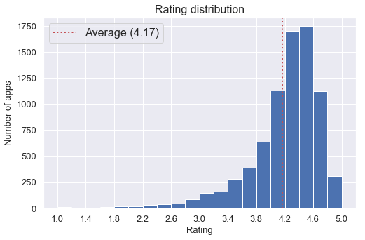

```python
bins = np.arange(1, 5.1, 0.2)
ave_rating = df['rating'].mean().round(2)
ax = df['rating'].plot.hist(bins=bins, label='')
ax.axvline(ave_rating, 0, 1, color='r', linestyle=':', lw=2, label='Average ({})'.format(ave_rating.round(2)))
plt.xticks(np.arange(1, 5.1, 0.4))
plt.legend(fontsize=16)
plt.xlabel('Rating')
plt.ylabel('Number of apps')
plt.title('Rating distribution')
print('Percentage of apps rated higher than the average:', (df['rating'] >= ave_rating).mean().round(2) * 100, '%')
```

## Popular Category

- `family` is the most popular category.
- `game` and `tools` are also popular.

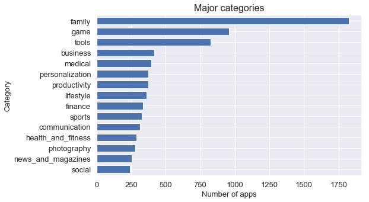

```python
total = df['category'].value_counts().sort_values()
major_categories = [x for x in total.index[-15:]]
total.iloc[-15:].plot.barh(figsize=(8, 5), color='b', width=0.7)
plt.xlabel('Number of apps')
plt.ylabel('Category')
plt.title('Major categories');
```

## Ratio of paid and free apps by categories

- `personalization` and `medical` apps tend not to be free.

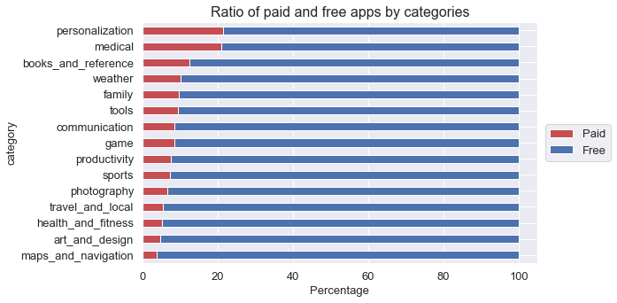

```python
perc = df.groupby(['category', 'type']).size().unstack().fillna(0)
perc = perc.apply(lambda x: 100 * x / x.sum(), axis=1).sort_values('Paid').iloc[-15:, ::-1]
perc.plot.barh(stacked=True, color=['r', 'b'], figsize=(8, 5))
plt.legend(bbox_to_anchor=(1.2, 0.5), loc='center right')
locs, labels = plt.yticks()
plt.title('Ratio of paid and free apps by categories')
plt.xlabel('Percentage');
```

## Price distribution by categories

- Most of paid apps are priced below $25.
- `medical` and `family` apps tend to be expensive.

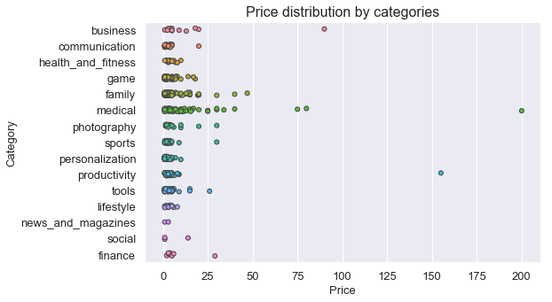

```python
df_subset = df[df['price'] > 0][df['category'].isin(major_categories)]
fig, ax = plt.subplots()
sb.stripplot(x='price', y='category', data=df_subset, jitter=True, linewidth=1)
plt.title('Price distribution by categories')
plt.xlabel('Price')
plt.ylabel('Category');
```

## App size distribution by categories

- For most of categories, app sizes skew to the right.
- `game` has a size different distribution where the number of light apps(< 20MB) is smaller compared to other categories. This is probably because games tend to require a lot of assets(image, sound, etc.) and codes to implement complex features.

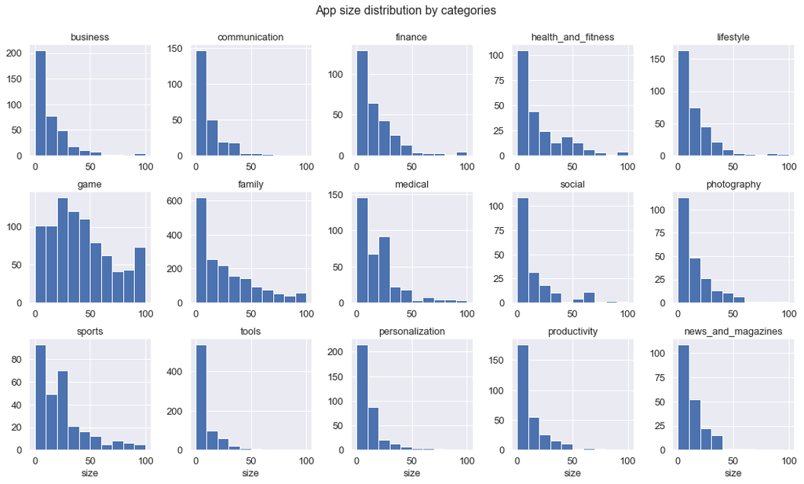

```python
df_subset = df[df['category'].isin(major_categories)]
bins = np.arange(0, 101, 10)
g = sb.FacetGrid(df_subset, col='category', col_wrap=5, sharex=False, sharey=False)
g = (g.map(plt.hist, 'size', bins=bins)).set_titles('{col_name}')
plt.subplots_adjust(top=0.9)
g.fig.suptitle('App size distribution by categories');
```

## Rating by categories

- Almost all major categories perform well.
- `health_and_fitness` is slightly better than the others.

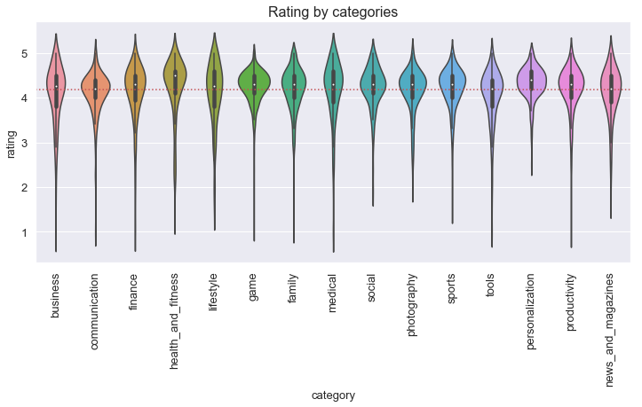

```python
fig, ax = plt.subplots()
fig.set_size_inches(12, 5)
p = sb.violinplot(data=df[df['category'].isin(major_categories)], x='category',y='rating')
# p = sb.violinplot(data=df, x='category',y='rating')
xlim = plt.xlim()
ax.plot(xlim,(ave_rating, ave_rating), 'r:')
ax.set_xlim(*xlim)
plt.xticks(rotation=90)
plt.title('Rating by categories')
plt.show()
```

## Rating vs Reviews for free and paid apps

- The relationship between `rating` and `reviews` is similar (positive correlation) for free and paid apps.
- Paid apps have less reivews than free apps. This is not surprising because people are more likely to install free apps.

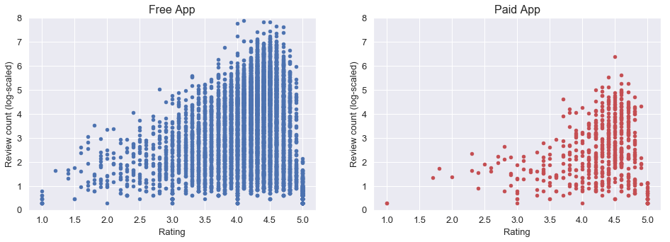

```python
fig, (ax1, ax2) = plt.subplots(ncols=2)
fig.set_size_inches(16, 5)
df[df['price'] == 0].plot.scatter('rating', 'reviews_log', color='b', ax=ax1)
ax1.set_xlabel('Rating')
ax1.set_ylabel('Review count (log-scaled)')
ax1.set_ylim(0, 8)
ax1.set_title('Free App')
df[df['price'] > 0].plot.scatter('rating', 'reviews_log', color='r', ax=ax2)
ax2.set_ylabel('Review count (log-scaled)')
ax2.set_xlabel('Rating')
ax2.set_ylim(0, 8)
ax2.set_title('Paid App');
```

# Conclusion